# Marvel Rivals performances!!!

[figure not shown]

An exploration of my teammates and my performance on the game Marvel Rivals which I logged in a google form periodically.

## Is my team even good? :(

Overall there are 26 victories and 22 defeats of the 48 players I logged.

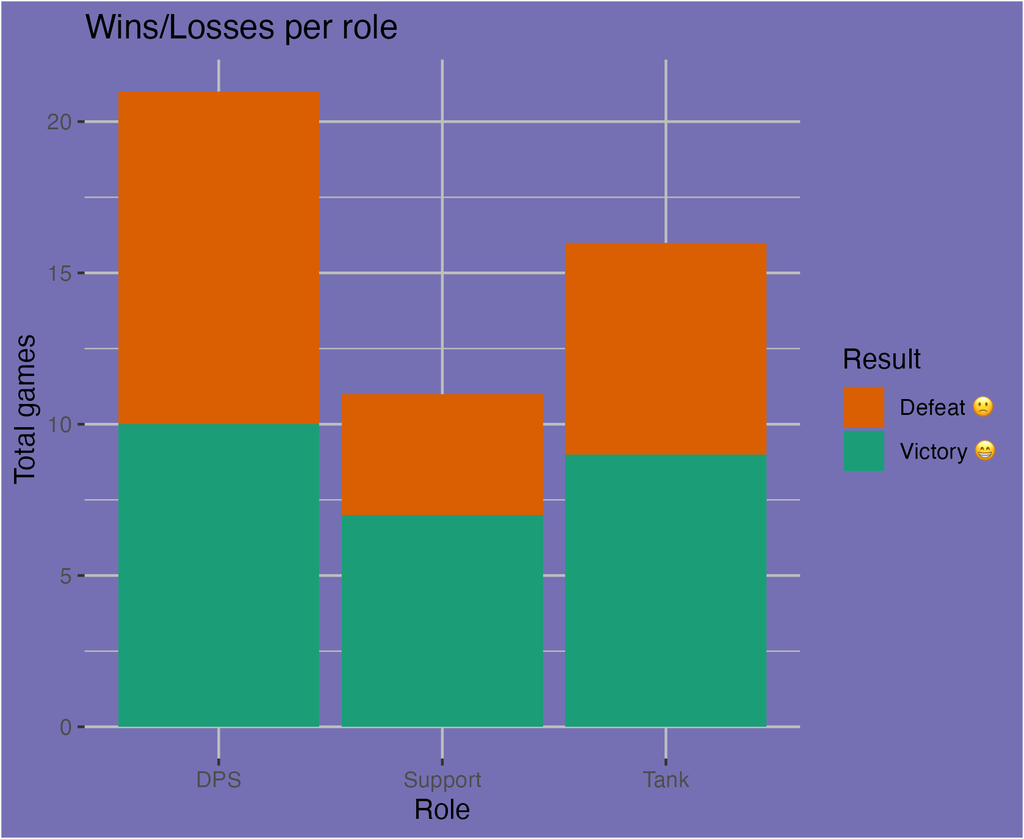

Support players had the best win/loss ratio whereas the DPS had the worst, this could be due to DPS players being more game-changing and their performance mattering more when it comes to the result of the game.

## Well did we at least get better? :(

Overall, no improvement better than others is seen.

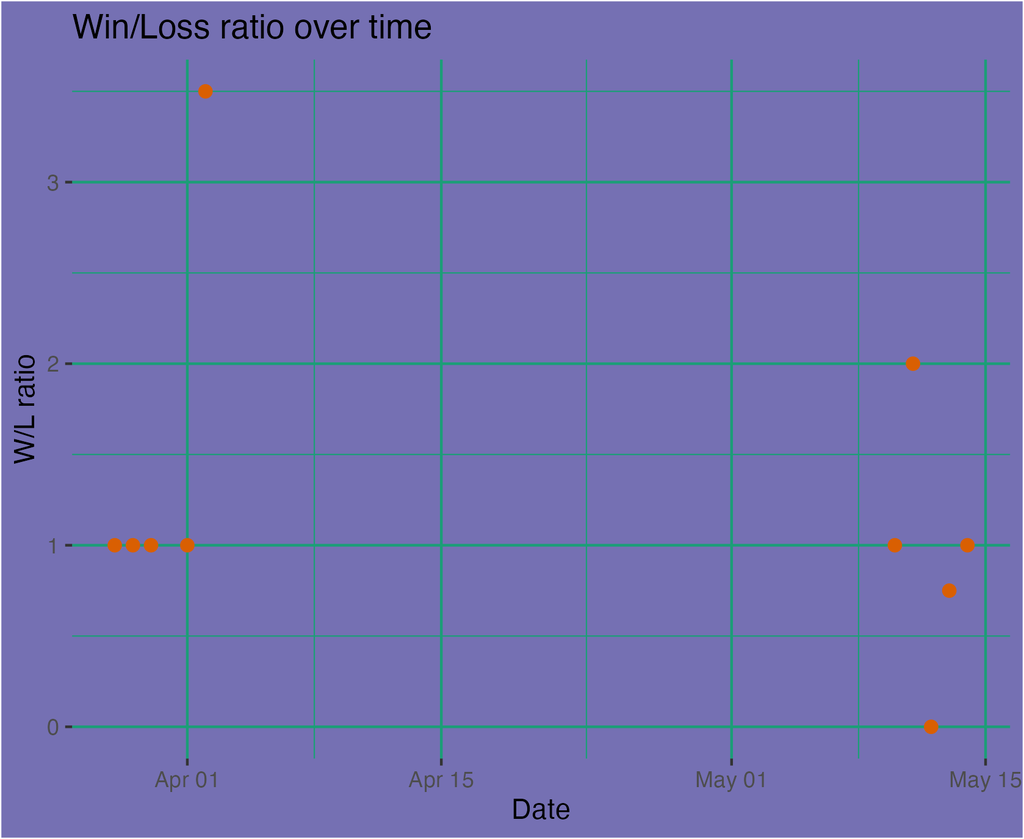

Win/Loss ratio over time

My win/loss ratio over time has stayed consistent with some outliers on good days, it seems my team and I haven’t improved at a much faster rate than other players but rather just stayed within the same skill gap.

## Is K/D affected by role choice?

Looking at the graph, it seems support players had the highest K/D’s on average.

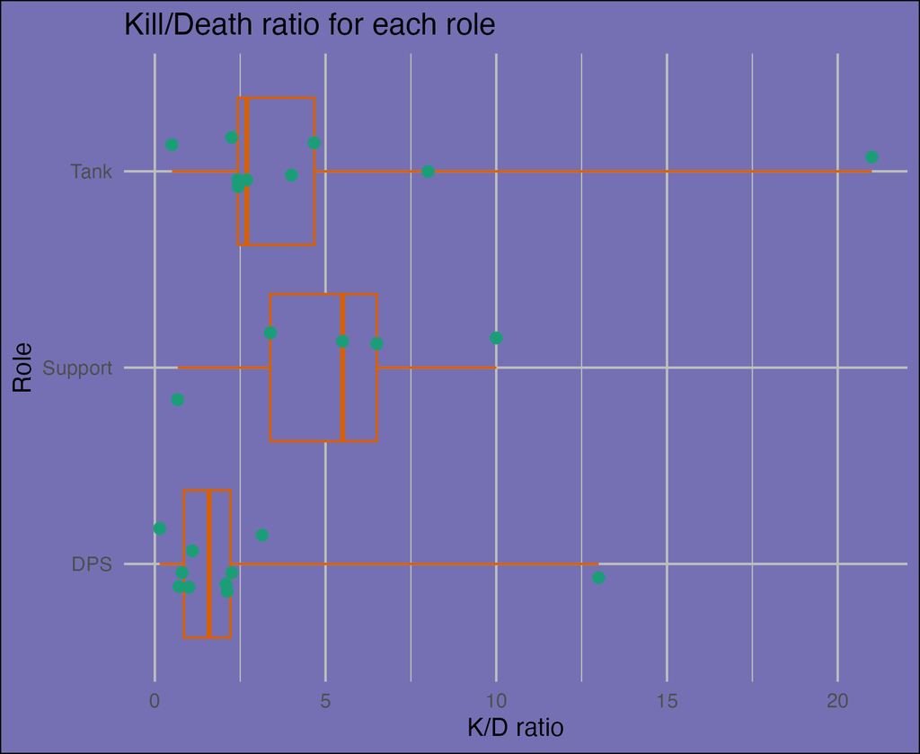

Support and Tank players seem to have an easier time getting more kills per death compared to DPS players, this could be due to the amount of sustainability they each have. Tanks having their larger health pool and supports having healing abilities. DPS players however have more risky and committal strategy and abilities which could lead to less kills per death on average than the other two roles.

## In Conclusion

Overall I learned I am no gaming prodigy :(

[figure not shown]

But I enjoy playing the game and that is what I play games for, the fun and the laughs with friends, however it is always more fun winning I suppose.